# 2021 Jay Yield Analysis Writeup

Jay Gillenwater

07 April, 2021

## Introduction

The purpose of this document is to record the data analysis process for the 2021 Jay Yield trial data. The goal is to provide set of methods, images, and relevant summary tables in that can be easily included in a more formal manuscript.

### Exploratory analysis

I’ll start with a high-level overview of the data itself. In total, there are 33 unique genotypes which were grown in three replications in four environments. These four environments consist of two growing years (2019 and 2020) with two growing locations per year. In 2019 the genotypes were grown in Kinston, NC (CAS), and the Tidewater Research Station (PLY), while in 2020, the genotypes were grown at the Central Crops Research Station (CLA), and the Kinston research farm (CAS).

**Summary table code**

```r
inspect(BalancedData, verbose = FALSE) %>%
    kbl(caption = "Basic summary data") %>%
    kable_styling(full_width = F, position = "left")
```

Basic summary data

Variable

Class

Missing

Levels

Valid_n

Min

Median

Max

Outlier

GEN

factor

No

33

396

NA

NA

NA

NA

REP

factor

No

3

396

NA

NA

NA

NA

ENV

factor

No

4

396

NA

NA

NA

NA

ag_score

numeric

No

396

1.00

2.50

5.00

0

HT

numeric

Yes

380

18.00

35.00

47.00

2

LOD

numeric

Yes

379

1.00

2.50

5.00

2

SDWT

numeric

Yes

330

12.30

16.55

20.70

0

Estimated_Seed_Count

numeric

Yes

330

1259.11

6538.46

13116.00

0

Yield

numeric

No

396

255.60

1671.59

3484.06

0

Oil

numeric

Yes

394

16.38

20.97

24.30

3

Protein

numeric

Yes

394

38.01

45.52

53.81

6

**Heatmap code**

Average phenotype measurements across genotypes and environemnts.

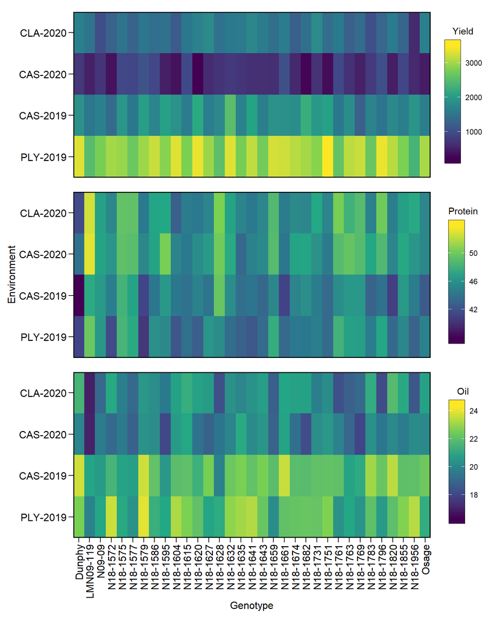

```r
# Plots showing the genotype x environment scores for yield, protein, and oil
  #TODO: Modify the ge_plot to produce a more compact, but still readable plot (Make a function for itkable)
  YieldPlot   <- ge_plot(Balanced_Data, GEN, ENV, Yield) + theme(axis.text.x = element_blank(),
                                                                 axis.ticks.x = element_blank(),
                                                                 axis.title.y = element_blank(),
                                                                 axis.title.x = element_blank())

  ProteinPlot <- ge_plot(Balanced_Data, GEN, ENV, Protein) + theme(axis.text.x = element_blank(),
                                                                   axis.ticks.x = element_blank(),
                                                                   axis.title.x = element_blank()) + labs(y = "Environment")

  OilPlot     <- ge_plot(Balanced_Data, GEN, ENV, Oil) + theme(axis.text.x = element_text(angle = 90, vjust = 0.5, hjust = 1),
                                                               axis.title.y = element_blank()) + labs(x = "Genotype")

  # Combine all three into a single plot with patchwork
 GenoByEnvironmentPlot <- YieldPlot / ProteinPlot / OilPlot
```

Inspection of the figure above reveals some general trends. Arguably the most prominent is in the yield data. It looks like the environment had a pretty substantial effect on yield, with genotypes in PLY-2019 tending to outperform nearly all other environments. On the other side of the coin, genotypes in CAS-2020 tended to yield far less than in other environments. A barplot of the yield scores for each genotype can be seen in the plot below where same general trends in yield can bee seen with some inspection.

**Barplot code**

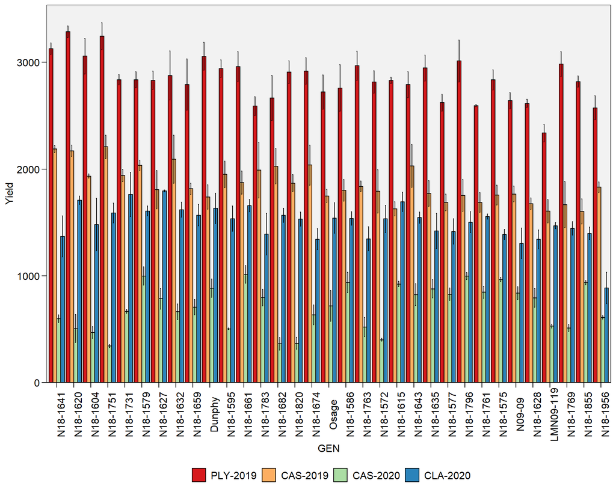

Yield scores for genotypes across four environments.

```r
# A barplot version of the above plot
 Yield_BarPlot <- BalancedData %>%
   mutate(GEN = fct_reorder(GEN, Yield, .desc = TRUE)) %>%
   plot_factlines(GEN, ENV, resp = Yield)

 Yield_BarPlot <- Yield_BarPlot + theme(axis.text.x = element_text(angle = 90, hjust = 0.5))
```

This is likely due to standing water that was present at that location during the growing season. Another, more subtle pattern that is revealed is the tendency for lines in the 2020 growing season to have slightly higher protein, and lower oil than in 2019. This was noticed when taking measurements on independent trials, and may be a systematic error from the NIR instrument instead of a physical change in seed composition.

These patterns may be easier to see in the plot below which shows the same data, but as a set of histograms.

**Plot code**

Histograms of seed oil, seed protein, and seed yield.

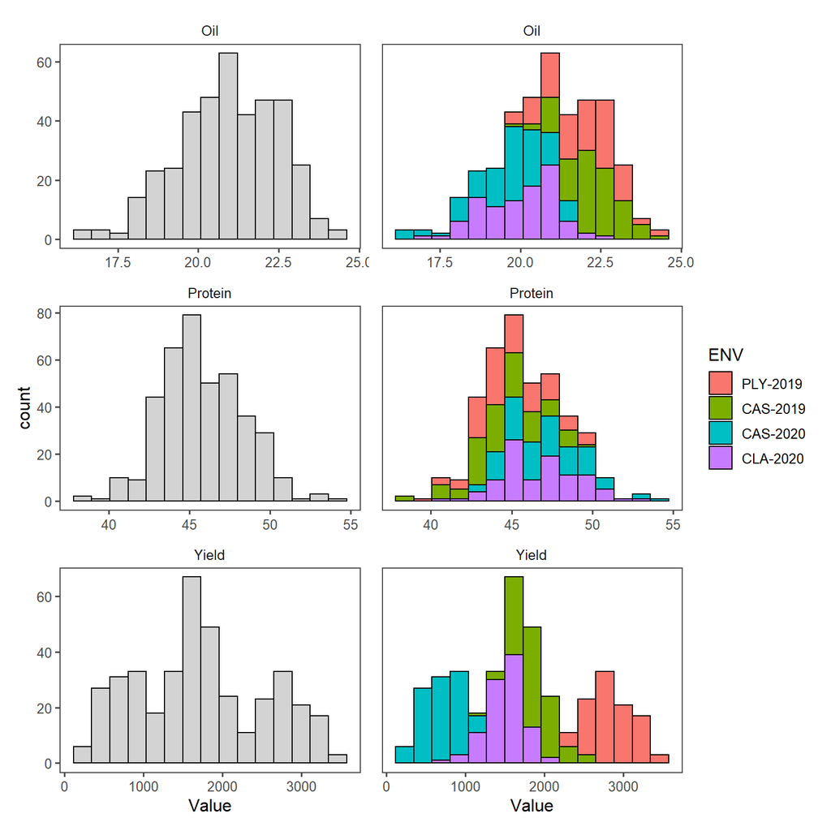

```r
# A function to make histograms for oil, protein, and yield
 MainTraitsHist <- function(BalancedData = Balanced_Data){

   Balanced_Data %>%
     dplyr::select(GEN, ENV, Yield, Oil, Protein) %>%
     pivot_longer(cols = 3:5, names_to = "Variable") -> PlotData


   Plots_BW <- ggplot(PlotData, aes(x = value)) +
     geom_histogram(bins = 15, colour = 'black', fill = 'light gray') +
     theme_few() +
     facet_wrap(~Variable, scales = "free", ncol = 1) +
     labs(x = "Value")


   Plots_colour <- ggplot(PlotData, aes(x = value, fill = ENV)) +
     geom_histogram(bins = 15, colour = 'black') +
     theme_few() +
     theme(axis.text.y  = element_blank(),
           axis.ticks.y = element_blank(),
           axis.title.y = element_blank()) +
     facet_wrap(~Variable, scales = "free", ncol = 1) +
     labs(x = "Value")

   Plots_BW + Plots_colour
 }

 MainTraitsPlot <- MainTraitsHist(BalancedData)
```

Even without coloring by location, it is obvious that there seems to be some factor influencing the distribution of yield, indicated by the multimodal distribution. Coloring the bars by location makes it more obvious that the environment is playing a substantial role in shaping these distributions. The patterns in protein in oil are more subtle, but still present as you can see that oil content tended to be higher in 2019, and the opposite for seed protein.

Next, I’ll look at the Pearson’s correlation matrix for the traits to get a sense for how each trait relates the others.

**Plot code**

Pearson’s correlation coefficients with p-values for measured traits.

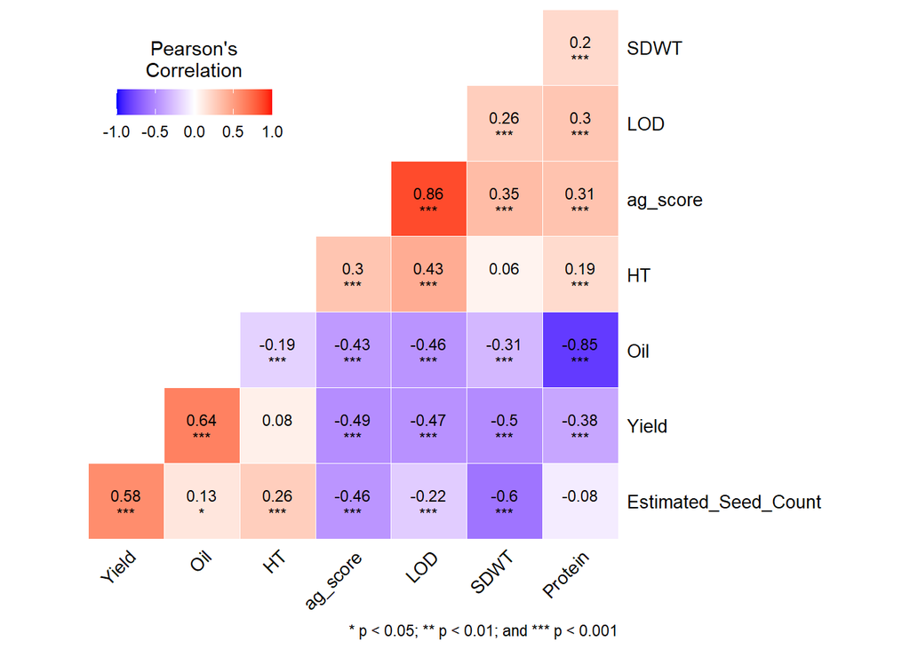

```r
CorrelationPlot <- corr_coef(Balanced_Data) %>% plot()
```

There are many significant (p <0.001) correlations among the traits. Some notable correlations with large magnitudes are between agscore and lodging, protein and oil, and yield and oil. These observations match well with previous observations on the correlation structure of these traits as protein and oil tend and yield and protein tend to have an inverse correlation with one another. The correlation between lodging and agscore is not surprising as heavily lodged plants were likely to get a poor (high) agscore as lodging is one of the most easily noticed physical properties which contributed to the agscore.

# Statistical modeling

## General purpose

At this point I think it would be worthwhile to go into more detail on the main objectives of this study. The overall objective is to identify soybean lines with exceptional yield, as well as seed oil and seed protein compositions. Exceptional in this context is judged by a genotypes performance relative to existing, high-yielding “check” cultivars which are already commonly grown for their desirable agronomic qualities. Lines with exceptional yield, oil, and protein are rare due to the correlation structure among these traits. As was illustrated in the correlation plot in the exploratory section, yield and protein content are negatively correlated with eachother, as are seed protein and seed oil. What this means in practice is that selecting genotypes on the basis of a single trait alone is likely to compromise the value of another trait which also contributes to the value of the crop.

Beyond their performance in these traits, it is important for the performance of the genotype relative to others to be reliable over a range of environments. It is common for environments to have some general effect on performance which to a difference in the overall mean of a trait between environments. A clear example of this can be seen by comparing the CAS-2020 and PLY-2019 environments in **figure 1**. However, of special interest is how environments effect the ranking of genotypes between environments. This change of ranking, and the degree to which a genotype’s performance deviates from what would be expected given the effect of the environment and the genotype alone is called genotype by environment interaction (GEI). In this context, *stability* means that the change in a genotypes performance for some trait between environments is equal to the change in the mean value of that trait between environments. Deviation from this expected change is an indicator of GEI. Substantial GEI is undesirable as it means growers cannot be sure that a genotype will be able to perform well.

Following this, what is needed is a way to systematically select genotypes on the basis of multiple traits, and accurately assess the stability of their performance in these traits across the environments which were used in this study. For the vast majority of the following analysis, I’ll be using the [metan](https://tiagoolivoto.github.io/metan/index.html) package in R, and the functions it provides to streamline the analysis of this kind of data(Olivoto, Lúcio, Silva, Marchioro, et al. 2019; Olivoto, Lúcio, Silva, Sari, et al. 2019).

## Linear Mixed Modeling (LMM)

**LMM code**

```r
fit_MixedModels <- function(BalancedData, TraitSelection = c("Yield", "Oil", "Protein")) {

  # Fit LMMs for the traits in TraitSelection
  MixedModels <- gamem_met(BalancedData,
                           env     = ENV,
                           gen     = GEN,
                           rep     = REP,
                           resp    = TraitSelection,
                           verbose = FALSE)

  # Extract various components and format here for easier presentation

  # The BLUPs
  ModelBLUPs <- get_model_data(MixedModels, "blupg")

  # Genetic paramaters
  ModelGenPar <- get_model_data(MixedModels, "genpar")

  # Combine all the components into a list fo easy reference
  ResultList <- list("BLUP"   = ModelBLUPs,
                     "GENPAR" = ModelGenPar)

  ResultList
}
```

For simplicity, I will give the results for just the yield, protein, and oil traits but the same methodology can apply to the other measured traits.

These models can be used to extract BLUPs and genetic parameters for the phenotypes.

**BLUPs**

BLUPs for selected traits.

| GEN | Yield | Oil | Protein |
| --- | --- | --- | --- |
| N18-1620 | 1767.94 | 21.33 | 44.01 |
| N18-1661 | 1758.81 | 22.12 | 43.33 |
| N18-1579 | 1757.31 | 21.77 | 43.72 |
| N18-1751 | 1752.33 | 21.09 | 44.57 |
| Dunphy | 1748.51 | 22.03 | 41.16 |
| N18-1641 | 1746.90 | 21.55 | 43.84 |
| N18-1796 | 1745.89 | 20.23 | 47.70 |
| N18-1632 | 1745.24 | 21.23 | 46.17 |
| N18-1627 | 1743.53 | 21.06 | 45.59 |
| N18-1731 | 1742.75 | 21.19 | 45.50 |
| N18-1643 | 1741.93 | 21.49 | 44.40 |
| N18-1615 | 1735.67 | 21.76 | 44.25 |
| N18-1586 | 1733.69 | 21.08 | 46.09 |
| N18-1635 | 1732.57 | 21.56 | 44.08 |
| N18-1575 | 1728.63 | 20.64 | 48.32 |
| N18-1604 | 1728.46 | 21.69 | 43.85 |
| N18-1674 | 1728.15 | 21.19 | 45.34 |
| N18-1595 | 1727.88 | 20.12 | 47.03 |
| N18-1659 | 1725.28 | 20.18 | 47.86 |
| N18-1783 | 1719.13 | 21.25 | 45.84 |
| N18-1855 | 1718.60 | 21.26 | 47.06 |
| Osage | 1717.11 | 21.22 | 44.75 |
| N18-1761 | 1714.61 | 19.94 | 48.70 |
| N18-1820 | 1714.22 | 21.72 | 43.75 |
| N18-1763 | 1713.92 | 20.01 | 47.76 |
| N18-1682 | 1711.51 | 21.01 | 45.23 |
| N18-1769 | 1710.43 | 19.81 | 47.84 |
| N18-1577 | 1707.62 | 19.84 | 48.41 |
| N09-09 | 1707.34 | 20.33 | 46.62 |
| N18-1572 | 1706.99 | 21.55 | 44.63 |
| N18-1628 | 1700.76 | 19.74 | 49.20 |
| LMN09-119 | 1674.64 | 18.95 | 50.52 |
| N18-1956 | 1672.32 | 21.48 | 44.93 |

**Genetic Parameters**

Genetic paramaters for selected traits.

| Parameters | Yield | Oil | Protein |
| --- | --- | --- | --- |
| Phenotypic variance | 56719.46 | 1.07 | 5.25 |
| Heritability | 0.04 | 0.62 | 0.82 |
| GEIr2 | 0.39 | 0.14 | 0.04 |
| h2mg | 0.22 | 0.92 | 0.97 |
| Accuracy | 0.46 | 0.96 | 0.99 |
| rge | 0.40 | 0.38 | 0.23 |
| CVg | 2.75 | 3.89 | 4.54 |
| CVr | 10.46 | 2.40 | 1.84 |
| CV ratio | 0.26 | 1.62 | 2.46 |

First, I’ll just look at the BLUPs for each genotype. The points in the plot below are colored blue if the genotypic BLUP is greater than the average BLUP for each trait, and red if the genotypic BLUP is lower than the average. The bars in each point show the 95% confidence interval for each BLUP.

**BLUP Plot code**

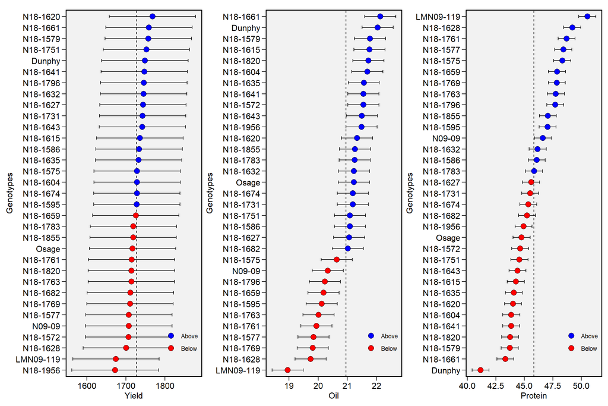

BLUPs for genotypes with 95% confidence intervals for seed yield, seed oil, and seed protein. Genotypes with BLUPs above the average for each trait are colored blue, while those with a BLUP below the average are colored red.

```r
  # The waasby models as fit by gamem_met
  ModelObjects <- MixedModels$ModelObjects

  # Plots for yield, oil, and protein BLUPs
  YieldPlot   <- plot_blup(ModelObjects, var = 1)
  OilPlot     <- plot_blup(ModelObjects, var = 2)
  ProteinPlot <- plot_blup(ModelObjects, var = 3)

  # Combine the three plots into one with patchwork
  AllThreeTraits <- YieldPlot | OilPlot | ProteinPlot
```

The same data is shown below as histograms. The positions of check cultivars, and parent genotypes are labeled on each distribution.

**BLUP Histogram Plot code**

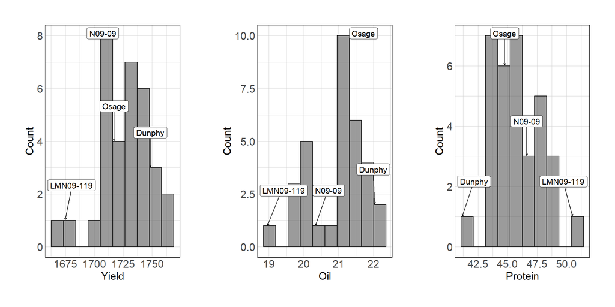

Histograms of BLUPs for seed yield, seed oil, and seed protein. The BLUPs for parents and checks are labeled for each trait.

```r
  # Histograms with the checks/parents labeled
  # A function to do this
  LabeledHistogram <- function(data, measure.vars = c("Protein", "Oil", "Yield"), labelColumn = "Genotype", labelObservations = c("LMN09-119", "N09-09")){

    # Pivot data to a long format
    longData <- data %>%
      pivot_longer(measure.vars)

    # The data for the "special" observations that need to be labeled
    specialObservations <- longData %>%
      dplyr::filter(!!sym(labelColumn) %in% labelObservations)

    # Split the dataframe by variable
    longData_split <- split(longData, longData$name)

    # Do the same for the special data
    specialObservations_split <- split(specialObservations, specialObservations$name)


    # The base plotting function. Takes as an argument a dataframe
    # containing measurements for a single phenotype (like AllPheno_long$oil)
    Plot_initial <- function(TraitData = longData_split$Oil, ParentData = specialObservations_split$Oil, TraitName = "Value"){

      # Get the initial plot
      Plot.init <-   ggplot(TraitData, aes(x = value)) +
        geom_histogram(color = "black", alpha = 0.6, bins = 10) +
        theme_bw() +
        ylab("Count") +
        theme_ipsum() +
        theme(axis.text.x  = element_text(face = "bold", size = 20),
              axis.text.y  = element_text(face = "bold", size = 20),
              axis.title.y = element_text(size = 25, hjust = 0.5),
              axis.title.x = element_text(size = 25, hjust = 0.5),
              panel.border = element_rect(colour = "black", fill = NA),
              legend.title = element_text(face = "bold", size = 20),
              legend.text  = element_text(face = "bold", size = 20)) +
        labs(x = TraitName)

      # Data from the initial plot (I want the bin heights)
      PlotData <- ggplot_build(Plot.init)$data[[1]]

      # Using the bin counts from the plot, find the y-value where the labels for each
      # check/parent genotype shoud start
      ParentData$yval <- NA
      for(i in 1:nrow(ParentData)){
        ParentData$yval[[i]] <- PlotData$count[[max(which(PlotData$xmin < ParentData$value[[i]]))]]
      }

      # Add labels w/arrows for the parents/checks using this new data
      FinalPlot <- Plot.init +
        ggrepel::geom_label_repel(data = ParentData,
                                  aes(x = value, y = yval, label = !!sym(labelColumn)),
                                  nudge_y            = max(PlotData$count)/6,
                                  arrow              = arrow(length = unit(0.015, "npc")),
                                  min.segment.length = 1,
                                  size               = 4,
                                  show.legend        = FALSE,
                                  inherit.aes        = FALSE)

      FinalPlot
    }

    AllPlots <- vector("list", length = length(longData_split))
    names(AllPlots) <- names(longData_split)
    for(Trait in names(longData_split)){
      AllPlots[[Trait]] <- Plot_initial(TraitData = longData_split[[Trait]], ParentData = specialObservations_split[[Trait]], TraitName = Trait)
    }

    #PatchPlot <- wrap_plots(AllPlots)
    PatchPlot <- AllPlots$Yield | AllPlots$Oil | AllPlots$Protein
  }

  # Use the function to make histograms of the BLUPs
  HistogramPlots <- LabeledHistogram(data = MixedModels$BLUP,
                                     labelColumn = "GEN",
                                     labelObservations = c("LMN09-119", "N09-09", "Osage", "Dunphy"))
```

From these plots I can make a few general observations. In both plots, you can see that several genotypes have yield BLUPs which are comparable with the Dunphy check cultivar. There was also fairly significant transgressive segregation for yield, but less so for seed oil and seed protein. The LMN09-119 parent had the lowest oil content, and the highest protein content. This is expected as it was selected based on it’s extreme values in those two traits.  
The confidence intervals of the yield BLUPs were much larger than those of the seed protein and oil measurements. This was expected given the aforementioned variability in yield for these genotypes across environments. **Unfortunately the upshot of this is it will be difficult to assert that a genotype truly is better (or worse) than any other with the current data**. You can see from the plot that all the genotypes fall within the 95% CI of the dunphy check cultivar. To give another point of reference, had a standard linear model been fit for analysis instead, the least significant difference for yield would be 292.5g, enough to encompass the full range of BLUPs. **This will have to be kept in mind while I proceed with additional analyses**.

While calculating the BLUPs helps to get an idea of how the genotypes performed in each trait independently, this technique is not able to provide information on the stability of the genotypes across the environments. Additionally, the ultimate goal of this study is to identify genotypes with yield comparebale to check cultivars, and seed protein and oil compositions which exceed that of the check cultivars. While the BLUPs provide good estimates of the ranking of the genotypes for each trait in isolation, they do not directly provide a method of ranking genotypes by considering multiple traits simultaneously.

## Stability analysis

It is important that the genotypes selected have *reliably* good performance in the traits under consideration. Many metrics exist to assess the stability of genotypes across environments. A starting point is with GGE biplot analysis(Yan and Tinker 2006).

**GGE Biplot code**

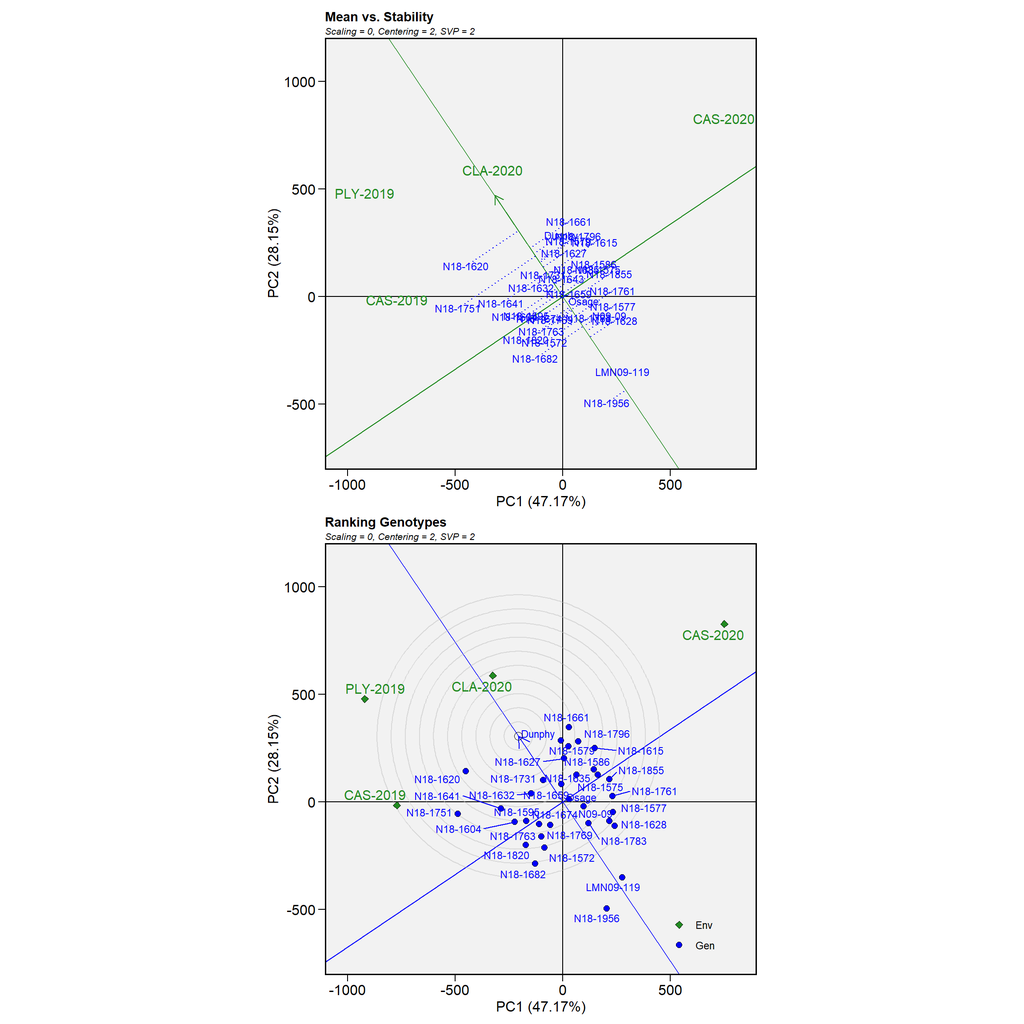

GGE Biplots to show mean vs stability of performance and the ranking of genotypes for seed yield.

```r
# Fit the GGE model with the gge function from metan
gge_model <- gge(BalancedData,
                   env  = ENV,
                   gen  = GEN,
                   resp = c("Yield", "Oil", "Protein"))

# The names associated with the numeric biplot types
  Biplot_type_names <- c("Basic" = 1,
                         "Mean performance vs stability" = 2,
                         "Which-won-where" = 3,
                         "Discriminativeness vs, representativeness" = 4,
                         "Examine an environment" = 5,
                         "Rank Environments" = 6,
                         "Examine a genotype" = 7,
                         "Rank genotypes" = 8,
                         "Compare two Genotypes" = 9,
                         "Relationship among environments" = 10)

  # For this study, I'm most interested in types 2, and 8.

  # A plotting function to return a single plot for all traits contained
  # in a gge model object
  GGE_Plot <- function(type = 2, GGEModel){

    # Get the names of the traits contained within the ggemodel object
    TraitNames <- names(GGEModel)

    # Make a list to hold all the plots
    PlotList        <- vector("list", length = length(GGEModel))
    names(PlotList) <- TraitNames

    for(i in 1:length(PlotList)){
        PlotList[[i]] <- plot(GGEModel, type = type, var = i, size.text.gen = 2)
    }

    # Combine the biplots for each trait into a single image
    arrange_ggplot(PlotList, tag_levels = list(TraitNames))
  }

  Type2Plot <- GGE_Plot(GGEModel = gge_model)
  Type8Plot <- GGE_Plot(type = 8, GGEModel = gge_model)

  # Arrange both plots into a single plot with patchwork
  AllTypes <- Type2Plot / Type8Plot

  AllTypes[[1]] <- AllTypes[[1]] + plot_layout(tag_level = 'new')
  AllTypes[[2]] <- AllTypes[[2]] + plot_layout(tag_level = 'new')

  Type2_8_GGEPlot <- AllTypes + plot_annotation(tag_levels = c('A', '1'))
```

Interpretating these plots merits some explanation. The upper plot is designed to visually rank genotypes on the basis of mean performance and stability across environments. The plot has a green axis marked with a green arrow. The position of genotypes along this line in the direction of the arrow indicate their mean performance, with genotypes further along the line in the direction of the arrow tending to perform better on average than those in the opposite direction of the arrow. The stability of a genotype can be assessed with this plot based on how away from this line it is, where genotypes located closer to the line are more stable than those which are further away.

The lower plot seeks to explicitely rank genotypes. A hypothetical “ideal” genotype which has the highest yield in all environments and is completely stable. This hypothetical perfect genotype is shown with the dark circle in the center of the concentric circles, and genotypes are ranked based on their distance from this genotype, with better genotypes located closer to the center.

Several observations are facilitated by these visualizations. First, we can see that the order of genotypes along the arrow in the first biplot matches the order of the BLUPs that we already calculated in the last section. What is added by this visualization beyond the BLUPs is an assessment of the stability of the genotypes across environments. We can see that while N18-1620 had the highest nominal yield, it was less stable than other comparable genotypes, like N18-1661, and the Dunphy check cultivar. These findings are reiterated in the second plot, where we can see that the Dunphy check cultivar was closest to the theoretical ideal, followed by N18-1661 and N18-1579.

Yield, however, is not the only trait of interest. It would be desirable to select genotypes on the basis of seed oil, and seed protein content as well. This is especially true for seed protein content as genotypes with both high yield and high protein are rare. This is illustrated in the data above as it can be seen that while the Dunphy check has among the highest and most consistent scores for yield, it performs nearly the worst in terms of protein content.

A simple extension of the biplot analysis is a so-called genotype by yield*trait analysis(Yan and Frégeau-Reid 2018). In the author’s own words, this evaluation based first on yield, then on other traits came from the following ideas:

> “1) Yield is the most important trait and all other traits are important only when combined with high yield. 2) The superiority of a genotype should be judged by its levels in combining yield with other traits, rather than by its value in individual traits.”

This concept matches closely with the goals of this study, and so I thought the technique should be considered for evaluating genotypes. Briefly, in this analysis, a new dataset is created from the product of yield scores with other agronomically valuable traits. This new dataset is then subjected to SVD in the same fashion as in traditional GGE analysis to create the biplot which is shown below.

**GYT Biplot code**

```r
  gytb(BalancedData,
                  gen       = GEN,
                  yield     = Yield,
                  traits    = c("Protein", "Oil", "ag_score", "LOD"),
                  ideotype  = c("h", "h", "l", "l"), # High values for protein and oil, low values for ag_score and LOD.
                  svp       = "genotype",            # Focused on differentiating genotypes
                  scaling   = 1,
                  centering = 2,
                  weight    = c(1, 1, 0.5, 0.5))     # Weight ag_score and lodging half as much as protein and oil (ag_score and lodging are already very correlated).
```

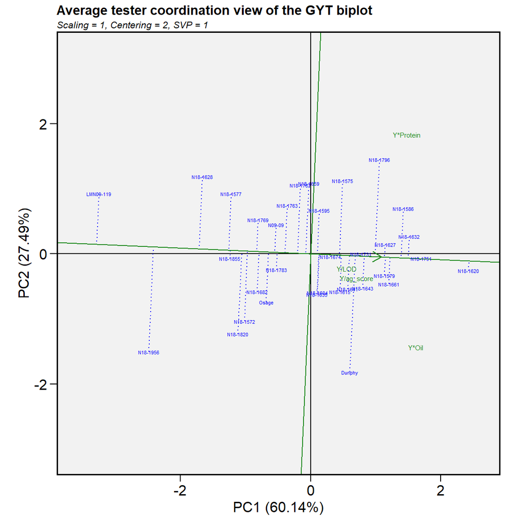

GYT biplot to show the combined relationships of genotypes performance of yield with seed protein, seed oil, lodging, and agronomic score.

This plot serves to rank genotypes based on all the traits used in the analysis. The plot is interpreted as follows:

- The green line with the single arrow head passes through the global average yield*trait combination and points towards higher values of these combinations. Genotypes further along this line in the direction of the arrow have higher rankings in terms of overall yield*trait combinations. Formally, this line is referred to as the average tester axis (ATA). Trait combinations such as Y/ag_score indicate that yield is divided by ag_score when creating the table for analysis. This is because lower values of ag_score are more desirable than high values.
- The vertical line that is perpendicular to the ATA passes through the average yield*trait value. Genotypes which lie to the right of this line have above average performance in the traits being evaluated, and genotypes to the left are below average.
- The distance from the ATA indicates the balance of the trait profile for a given genotype. Genotypes placed close to the ATA have balanced profiles in the given traits while Genotypes placed further from the ATA have unbalanced profiles which tend to favor one trait over the other.

For example, the N18-1796 line is to the right of the mean line, is relatively far along the ATA, and is relatively far from the ATA in the direction of Y*Protein. From this we can gather that this genotype has above average performance in yield, seed oil, and seed protein, and it favors seed protein over seed oil, lodging, and agronomic score.

The GYT analysis can then be used to derive a superiority index based on the combined values of yield with the traits. This can then be used to rank the genotypes according to their multi-trait performance.

**Superiority Indices**

Superiority Indices drived from the GYT biplot for yield, seed oil, seed protein, lodging, and agronomic score.

| GEN | SI |
| --- | --- |
| N18-1620 | 4.76 |
| N18-1751 | 3.12 |
| N18-1632 | 2.76 |
| N18-1627 | 2.63 |
| N18-1586 | 2.37 |
| Dunphy | 1.98 |
| N18-1643 | 1.98 |
| N18-1796 | 1.65 |
| N18-1579 | 1.51 |
| N18-1661 | 1.48 |
| N18-1731 | 1.30 |
| N18-1615 | 1.14 |
| N18-1575 | 0.78 |
| N18-1761 | 0.50 |
| N18-1641 | 0.38 |
| N18-1674 | 0.20 |
| N18-1595 | 0.18 |
| N18-1659 | 0.04 |
| N18-1635 | -0.09 |
| Osage | -0.49 |
| N18-1604 | -0.52 |
| N09-09 | -0.77 |
| N18-1763 | -0.77 |
| N18-1769 | -0.86 |
| N18-1783 | -0.93 |
| N18-1682 | -1.39 |
| N18-1820 | -1.92 |
| N18-1572 | -1.92 |
| N18-1855 | -2.23 |
| N18-1577 | -2.40 |
| N18-1628 | -3.52 |
| N18-1956 | -4.60 |
| LMN09-119 | -6.32 |

Lets see where some of these exceptional lines fall on the overall distributions for the three traits.

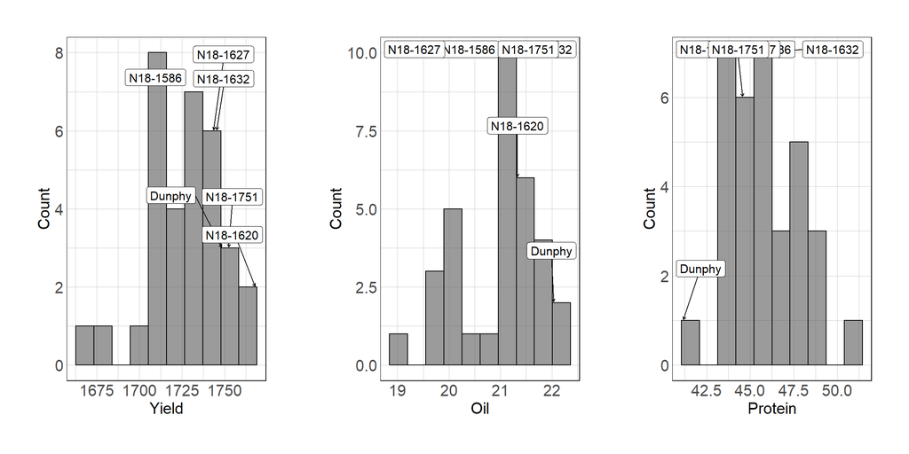

Histograms of BLUPs for seed yield, seed oil, and seed protein. Labels have been added for some of the genotypes identified in the last section.

## Reproducibility

**Reproducibility receipt**

```
## [1] "2021-04-07 21:54:46 EDT"
```

```
## Local:    main C:/Users/Jay/Desktop/Documents/R/JayYield2021
## Remote:   main @ origin (https://github.com/jhgille2/JayYield2021.git)
## Head:     [536a8a9] 2021-04-08: Rename doc to docs, re-run pipeline
```

# References

Olivoto, Tiago, Alessandro D. C. Lúcio, José A. G. da Silva, Volmir S. Marchioro, Velci Q. de Souza, and Evandro Jost. 2019. “Mean Performance and Stability in Multi‐environment Trials i: Combining Features of AMMI and BLUP Techniques.” Journal Article. *Agronomy Journal* 111 (6): 2949–60.

Olivoto, Tiago, Alessandro D. C. Lúcio, José A. G. da Silva, Bruno G. Sari, and Maria I. Diel. 2019. “Mean Performance and Stability in Multi‐environment Trials II: Selection Based on Multiple Traits.” Journal Article. *Agronomy Journal* 111 (6): 2961–69.

Yan, Weikai, and Judith Frégeau-Reid. 2018. “Genotype by Yield* Trait (GYT) Biplot: A Novel Approach for Genotype Selection Based on Multiple Traits.” *Scientific Reports* 8 (1): 1–10.

Yan, Weikai, and Nicholas A Tinker. 2006. “Biplot Analysis of Multi-Environment Trial Data: Principles and Applications.” *Canadian Journal of Plant Science* 86 (3): 623–45.